# Homework #4

Kobe Pranivong; illuminobe

3/4/2020

## Chick weights

1. Get a frequency breakdown of the number of chicks, their average weight and the standard deviation of the weights in each of the diets at the start of the study. Store the resulting data frame in a variable named `weight0` and print.

```r
df = ChickWeight

weight0 = df %>%
  group_by(Diet) %>%
  filter(Time == 0) %>%
  summarize(Avg_weight = mean(weight, na.rm=TRUE), Std_Dev = sd(weight, na.rm=TRUE), Number_of_chicks = length(unique(Chick)))
print(weight0)
```

```
## # A tibble: 4 x 4
##   Diet  Avg_weight Std_Dev Number_of_chicks
##   <fct>      <dbl>   <dbl>            <int>
## 1 1           41.4   0.995               20
## 2 2           40.7   1.49                10
## 3 3           40.8   1.03                10
## 4 4           41     1.05                10
```

Extra Credit: Construct a ggplot that shows average weights by diet with an interval (shown as a line) of +- the standard deviation around the averages.

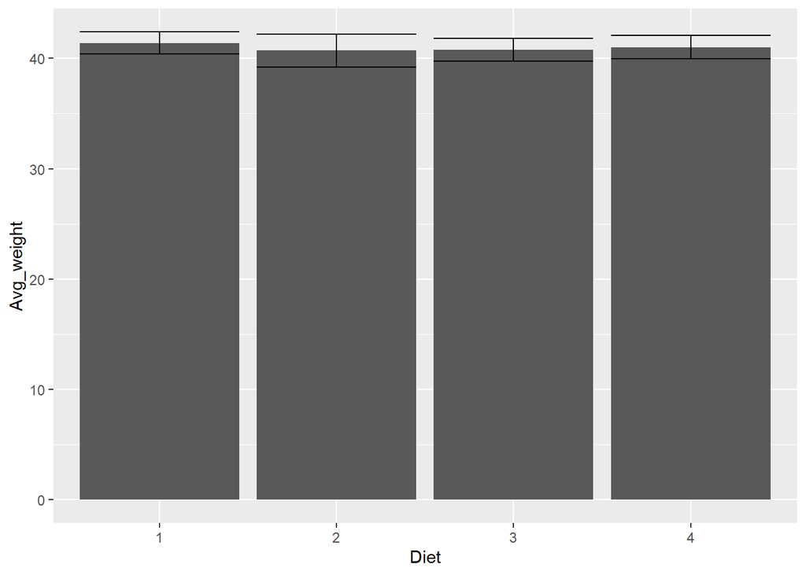

```r
xtra <- ggplot(weight0, aes(x=Diet, y=Avg_weight)) + geom_bar(stat="identity") + geom_errorbar(aes(ymin=Avg_weight-Std_Dev, ymax=Avg_weight+Std_Dev))
xtra
```

2. Each chick should have twelve weight measurements. Use the `dplyr` package to identify how many measurements are there for each chick. Extract a subset of the data for all chicks with complete information, name the data set `complete`, and print the first 3 rows. (Hint: you might want to use mutate to introduce a helper variable consisting of the number of observations)

```r
# Checking for chicks with twelve weight measurements
a <- ChickWeight %>%
  group_by(Chick) %>%
  summarize(n = n()) %>%
  filter(n == 12) %>%
  select(-n)
# Extracting a subset of the data for all chicks with complete information
Chicks <- ChickWeight
Chicks$Chick <- as.numeric(Chicks$Chick)
a$Chick <- as.numeric(a$Chick)
complete <- filter(Chicks, Chicks$Chick %in% a$Chick)
complete$Chick <- as.factor(complete$Chick)
head(complete, 3)
```

```
##   weight Time Chick Diet
## 1     42    0    15    1
## 2     51    2    15    1
## 3     59    4    15    1
```

3. In the complete data set introduce a new variable that measures the current weight difference compared to day 0. Name this variable `weightgain` and print the first 3 rows of the new data frame.

```r
weightgain = complete %>%
  group_by(Chick) %>%
  mutate(Weight_gain = weight - weight[Time == 0])
weightgain[1:3, ]
```

```
## # A tibble: 3 x 5
## # Groups:   Chick [1]
##   weight  Time Chick Diet  Weight_gain
##    <dbl> <dbl> <fct> <fct>       <dbl>
## 1     42     0 15    1               0
## 2     51     2 15    1               9
## 3     59     4 15    1              17
```

4. Use `{ggplot2}` to create side-by-side boxplots of `weightgain` by `Diet` for day 21. Change the order of the categories in the Diet variable such that the boxplots are ordered by median `weightgain`, and the lower limit of the y axis should be 0. Describe the relationship in 2-3 sentences.

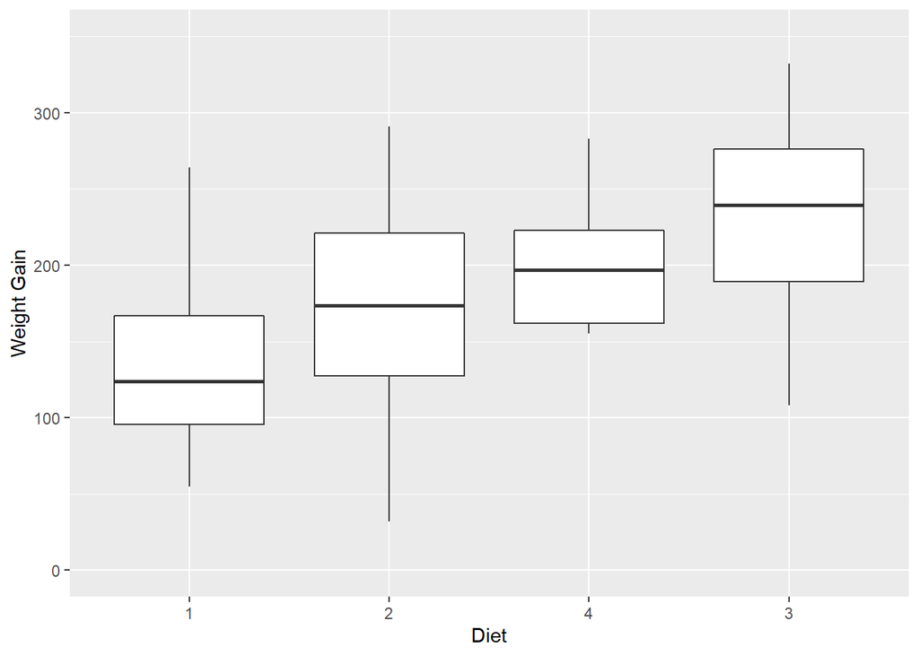

```r
df1 <- filter(weightgain, Time == 21)
ggplot(df1, aes(x=reorder(Diet, Weight_gain, median), y=Weight_gain)) + geom_boxplot() + labs(x = "Diet", y = "Weight Gain") + ylim(c(0, 350))
```

It seems like the diet with the lowest amounts of weight gain is #1 and the diet with the highest amounts of weight gain is #3. Although diet #2 has a minimum lower than diet #1, about 75% of diet #1’s data is below diet #2’s median; which means it typically has lower weight gain.

5. Answer each of the following questions using numerical and graphical summary. Also explain what you found: (a) Which chick gained the most weight and which gained the least weight? (b) What diets were they on?

```r
total_gain <- weightgain %>%
  group_by(Chick) %>%
  filter(Time == max(weightgain$Time)) %>%
  arrange(Weight_gain)
# Numerical summary
total_gain$Chick = as.numeric(levels(total_gain$Chick)[total_gain$Chick])
cat(sep="", "Lowest Chick: ", total_gain$Chick[1], ", Diet: ", total_gain$Diet[1], "\n")
```

```
## Lowest Chick: 21, Diet: 2
```

```r
cat(sep="", "Highest Chick: ", total_gain$Chick[dim(total_gain)[1]], ", Diet: ", total_gain$Diet[dim(total_gain)[1]])
```

```
## Highest Chick: 40, Diet: 3
```

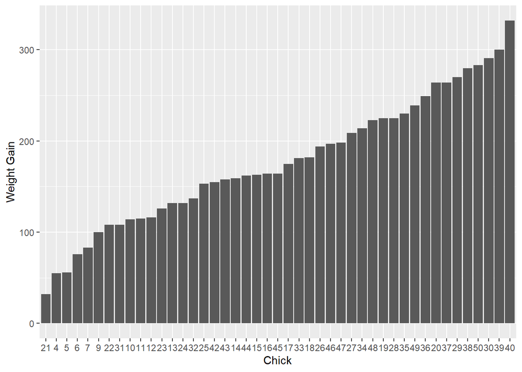

```r
# Graphical summary
ggplot(total_gain, aes(x = reorder(Chick, Weight_gain, abs), y = Weight_gain)) + geom_col() + labs(x = "Chick", y = "Weight Gain")
```

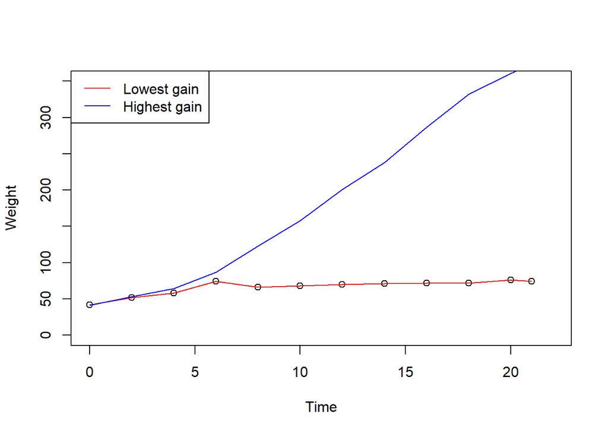

```r
total_gain <- weightgain %>%
  group_by(Chick) %>%
  filter(Time == max(weightgain$Time)) %>%
  arrange(Weight_gain)

least_weight = total_gain$Chick[1]
# Lowest
least_weight_data = complete %>%
  filter(Chick == least_weight)
time = least_weight_data$Time
least_weight_total = least_weight_data$weight
# Highest
most_weight = total_gain$Chick[dim(total_gain)[1]]
most_weight_data = complete %>%
  filter(Chick == most_weight)
most_weight_total = most_weight_data$weight

plot(x = time, y = least_weight_total, xlab="Time", ylab="Weight", xlim=c(0, 22), ylim=c(0, 350))
lines(x = time, y = least_weight_total, col="red", lty=1)
lines(x = time, y = most_weight_total, col="blue", lty=1)
legend("topleft", legend=c("Lowest gain", "Highest gain"), col=c("red", "blue"), lty=c(1,1))
```

7. Add to the previous plot the average growth trajectory for all chicks (calculated as the mean weight for each chick at each time). How do the trajectories compare?

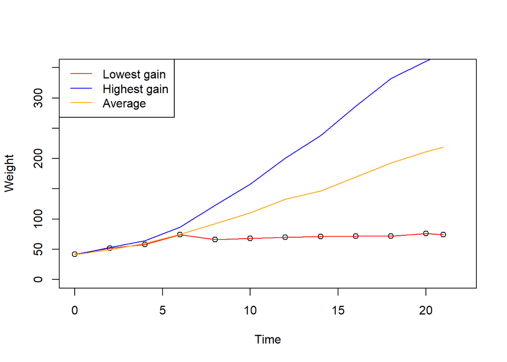

```r
v = rep(0, length(time))
for(i in seq_len(length(time))) {
  v[i] = mean(weightgain$weight[weightgain$Time == time[i]])
}
# Add to the previous plot
plot(x = time, y = least_weight_total, xlab="Time", ylab="Weight", xlim=c(0, 22), ylim=c(0, 350))
lines(x = time, y = least_weight_total, col="red", lty=1)
lines(x = time, y = most_weight_total, col="blue", lty=1)
lines(x = time, y = v, col="orange", lty=1)
legend("topleft", legend=c("Lowest gain", "Highest gain", "Average"), col=c("red", "blue", "orange"), lty=c(1,1, 1))
```

8. What else do you find interesting in the dataset? Show your exploratory analysis.

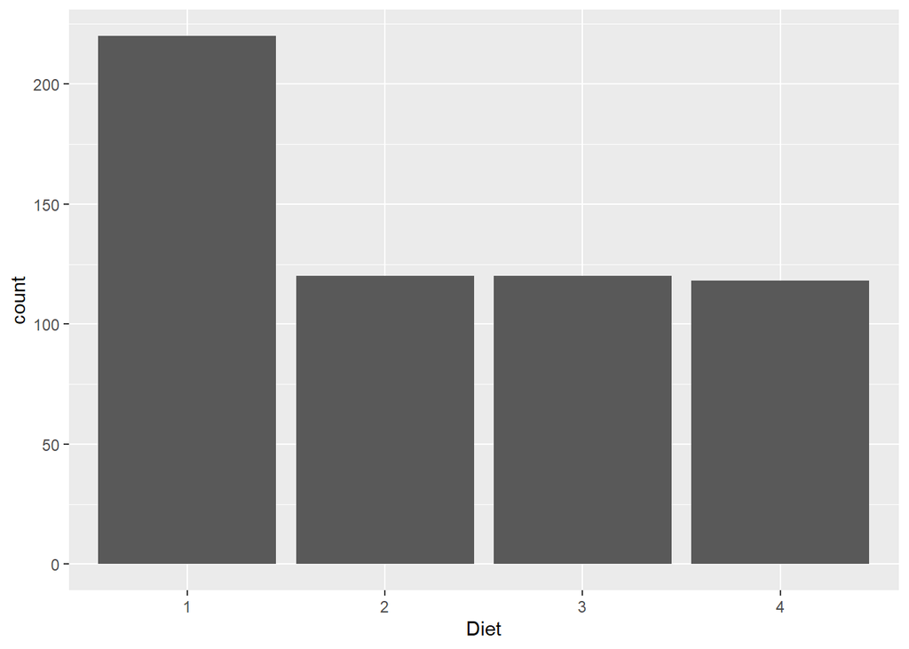

```r
ggplot(ChickWeight, aes(x=Diet)) + geom_histogram(stat="count")
```

Diet 1 was the most frequent diet.